# Project: Insurance Policy Cancellation

### *This dataset comes from the 2022 NESS Statathon (Theme 1) from 2022.*

### **Challenge:** Using historical policy data, create a multiclass predictive model to predict the policies that are most likely to be canceled and those most likely to be renewed, as well as understand what variables are most influential in causing a policy cancellation.

# Dataset Description

The Kangaroo data set is based on 4 years of property insurance policies from 2013 to 2017. There are roughly 1 million policies in the training data and each policy only has one observation. There were almost 230,000 policies canceled during the effective term.

Variable descriptions

- id - Policy id (cannot be used in model)
- tenure - Number of years with Kangaroo
- claim.ind - Occurrence of claim (0=no, 1=yes)
- n.adults - Number of adults in the property
- n.children - Number of children in the property
- ni.gender - Gender of policyholder
- ni.marital.status - Marital status of policyholder (0=no, 1=yes)
- premium - Price of the policy
- sales.channel - Medium through which policy was purchased
- coverage.type - Type of coverage
- dwelling.type - Type of dwelling
- len.at.res - Length at residence (how long policyholder lived at property)
- credit - Financial credit level of policyholder
- house.color - Color of house
- ni.age - Age of policholder
- year - Year of the policy
- zip.code - Zip code of the property
- cancel - cancelation indicator (0=not cancel, 1=may cancel but can be convinced, 2=cancel).

```python
# https://drive.google.com/file/d/1cF4YgsHb6jWoM8s1oMckCE5DXz71dJIr/view?usp=share_link
# https://drive.google.com/file/d/1k8asF0dptYNn1DFkylSEpr0D9FstpIO4/view?usp=share_link
# https://drive.google.com/file/d/1nldFnY3-FBKDvfpyLXjD9uxm7d7SLo6n/view?usp=share_link
# https://drive.google.com/file/d/1VirvGGFaqg1ifPjgO0MzHg3Bc7KuwotG/view?usp=share_link

!gdown 1cF4YgsHb6jWoM8s1oMckCE5DXz71dJIr
!gdown 1k8asF0dptYNn1DFkylSEpr0D9FstpIO4
!gdown 1nldFnY3-FBKDvfpyLXjD9uxm7d7SLo6n
!gdown 1VirvGGFaqg1ifPjgO0MzHg3Bc7KuwotG
```

```
Downloading...
From: https://drive.google.com/uc?id=1cF4YgsHb6jWoM8s1oMckCE5DXz71dJIr
To: /content/X_test.csv
100% 31.5M/31.5M [00:00<00:00, 91.6MB/s]
Downloading...
From: https://drive.google.com/uc?id=1k8asF0dptYNn1DFkylSEpr0D9FstpIO4
To: /content/X_train.csv
100% 63.9M/63.9M [00:00<00:00, 88.5MB/s]
Downloading...
From: https://drive.google.com/uc?id=1nldFnY3-FBKDvfpyLXjD9uxm7d7SLo6n
To: /content/y_test.csv
100% 690k/690k [00:00<00:00, 60.9MB/s]
Downloading...
From: https://drive.google.com/uc?id=1VirvGGFaqg1ifPjgO0MzHg3Bc7KuwotG
To: /content/y_train.csv
100% 1.40M/1.40M [00:00<00:00, 31.0MB/s]
```

# Imports and Data Loading

## Importing required modules

```python
import warnings
warnings.filterwarnings('error', category=DeprecationWarning)
```

```python
#importing required modules

# Utility imports
import pandas as pd
import numpy as np
import matplotlib.pyplot as plt
import seaborn as sns

#Data Preprocessing imports
from sklearn.preprocessing import LabelEncoder, MinMaxScaler
from imblearn.over_sampling import RandomOverSampler
from collections import Counter

# Classifiers imports
from sklearn.tree import DecisionTreeClassifier
from sklearn.ensemble import RandomForestClassifier, GradientBoostingClassifier, BaggingClassifier, AdaBoostClassifier, ExtraTreesClassifier
from sklearn.linear_model import LogisticRegression
from sklearn.neural_network import MLPClassifier
from sklearn.naive_bayes import GaussianNB
from sklearn.neighbors import KNeighborsClassifier

# mertics imports
from sklearn.metrics import classification_report, f1_score, accuracy_score, confusion_matrix

# For permutation_importance and ice_plots
from sklearn.inspection import permutation_importance
from pycebox.ice import ice, ice_plot
```

## Loading datasets

```python
#loading data sets
# I have loaded datasets from Google Drive.
X_train =  pd.read_csv('C:\\Users\\Sowmya\\Downloads\\X_train.csv')
X_test = pd.read_csv('C:\\Users\\Sowmya\\Downloads\\X_test.csv')
y_train = pd.read_csv('C:\\Users\\Sowmya\\Downloads\\y_train.csv')
y_test= pd.read_csv('C:\\Users\\Sowmya\Downloads\\y_test.csv')
```

# Dataset Information

Let us observe the properties of each of X_train, X_test, y_train and y_test. More precisely, we will look into the missing values, columns, and relavant information for data.

## Train Data Information

```python
print(f"X_train shape: {X_train.shape}")
#There are 700232 rows and 17 columns in X_train

print(f"y_train shape: {y_train.shape}")
#There are 700232 rows and 1 column in y_train, which is a target variable(cancel)
```

```
X_train shape: (700232, 17)
y_train shape: (700232, 1)
```

In the below cell, we get the following for Train Dataset:

1. Features of the dataset
2. Datatype of each feature
3. Count of Non-Null values in each column

```python
#Let us look at the dataset.info()

print('---------------------X_train Info------------------------------------')
print(X_train.info())


print('---------------------y_train Info------------------------------------')
print(y_train.info())
```

```
---------------------X_train Info------------------------------------
<class 'pandas.core.frame.DataFrame'>
RangeIndex: 700232 entries, 0 to 700231
Data columns (total 17 columns):
 #   Column             Non-Null Count   Dtype
---  ------             --------------   -----
 0   id                 700232 non-null  int64
 1   year               700232 non-null  int64
 2   zip.code           699601 non-null  float64
 3   house.color        699612 non-null  object
 4   ni.age             699524 non-null  float64
 5   len.at.res         699567 non-null  float64
 6   credit             699616 non-null  object
 7   coverage.type      699569 non-null  object
 8   dwelling.type      699581 non-null  object
 9   premium            699608 non-null  float64
 10  sales.channel      699536 non-null  object
 11  ni.gender          699589 non-null  object
 12  ni.marital.status  699585 non-null  float64
 13  n.adults           699626 non-null  float64
 14  n.children         699616 non-null  float64
 15  tenure             699577 non-null  float64
 16  claim.ind          699574 non-null  float64
dtypes: float64(9), int64(2), object(6)
memory usage: 90.8+ MB
None
---------------------y_train Info------------------------------------
<class 'pandas.core.frame.DataFrame'>
RangeIndex: 700232 entries, 0 to 700231
Data columns (total 1 columns):
 #   Column  Non-Null Count   Dtype
---  ------  --------------   -----
 0   cancel  700232 non-null  int64
dtypes: int64(1)
memory usage: 5.3 MB
None
```

```python
#Let us see X_train.head()
X_train.head()
```

|  | id | year | zip.code | house.color | ni.age | len.at.res | credit | coverage.type | dwelling.type | premium | sales.channel | ni.gender | ni.marital.status | n.adults | n.children | tenure | claim.ind |
| --- | --- | --- | --- | --- | --- | --- | --- | --- | --- | --- | --- | --- | --- | --- | --- | --- | --- |
| 0 | 942391 | 2013 | 15056.0 | yellow | 55.0 | 15.0 | high | A | House | 935.554116 | Phone | F | 1.0 | 1.0 | 1.0 | 14.0 | 0.0 |
| 1 | 2792 | 2014 | 80014.0 | red | 60.0 | 17.0 | medium | A | House | 835.804218 | Phone | F | 1.0 | 1.0 | 1.0 | 17.0 | 0.0 |
| 2 | 282556 | 2014 | 85002.0 | white | 48.0 | 15.0 | high | A | Condo | 958.488416 | Broker | M | 1.0 | 1.0 | 0.0 | 11.0 | 1.0 |
| 3 | 738330 | 2014 | 85051.0 | red | 57.0 | 15.0 | high | A | House | 963.496010 | Phone | F | 1.0 | 2.0 | 1.0 | 19.0 | 0.0 |
| 4 | 243724 | 2013 | 85077.0 | white | 42.0 | 16.0 | high | B | House | 803.088375 | Broker | F | 1.0 | 2.0 | 2.0 | 12.0 | 0.0 |

## Test Data Information

```python
print(f"X_test shape: {X_test.shape}")
#There are 3448891 rows and 17 columns in X_test

print(f"y_test shape: {y_test.shape}")
#There are 344891 rows and 1 column in y_test, which is a target variable(cancel)
```

```
X_test shape: (344891, 17)
y_test shape: (344891, 1)
```

In the below cell, we get the following for Test Dataset:

1. Features of the dataset
2. Datatype of each feature
3. Count of Non-Null values in each column

```python
#Let us look at the dataset.info()

print('---------------------X_test Info------------------------------------')
print(X_test.info())


print('---------------------y_test Info------------------------------------')
print(y_test.info())
```

```
---------------------X_test Info------------------------------------
<class 'pandas.core.frame.DataFrame'>
RangeIndex: 344891 entries, 0 to 344890
Data columns (total 17 columns):
 #   Column             Non-Null Count   Dtype
---  ------             --------------   -----
 0   id                 344891 non-null  int64
 1   year               344891 non-null  int64
 2   zip.code           344578 non-null  float64
 3   house.color        344572 non-null  object
 4   ni.age             344598 non-null  float64
 5   len.at.res         344596 non-null  float64
 6   credit             344602 non-null  object
 7   coverage.type      344575 non-null  object
 8   dwelling.type      344552 non-null  object
 9   premium            344560 non-null  float64
 10  sales.channel      344567 non-null  object
 11  ni.gender          344577 non-null  object
 12  ni.marital.status  344546 non-null  float64
 13  n.adults           344568 non-null  float64
 14  n.children         344572 non-null  float64
 15  tenure             344568 non-null  float64
 16  claim.ind          344567 non-null  float64
dtypes: float64(9), int64(2), object(6)
memory usage: 44.7+ MB
None
---------------------y_test Info------------------------------------
<class 'pandas.core.frame.DataFrame'>
RangeIndex: 344891 entries, 0 to 344890
Data columns (total 1 columns):
 #   Column  Non-Null Count   Dtype
---  ------  --------------   -----
 0   cancel  344891 non-null  int64
dtypes: int64(1)
memory usage: 2.6 MB
None
```

# Data Preprocessing

Eliminating id feature as it is not useful for modelling and only useful for indexing.

```python
X_train.drop("id", axis = 1, inplace=True)
X_test.drop("id", axis=1, inplace=True)
```

## Imputation for Train data

```python
X_train.isna().sum()
#All features except year have missing values with number of missing values ranging from 606 to 708
```

```
year                   0
zip.code             631
house.color          620
ni.age               708
len.at.res           665
credit               616
coverage.type        663
dwelling.type        651
premium              624
sales.channel        696
ni.gender            643
ni.marital.status    647
n.adults             606
n.children           616
tenure               655
claim.ind            658
dtype: int64
```

```python
#This list contains the features that we want to impute with the mean. These are mostly continuous variables.
continous_features = ['zip.code', 'ni.age', 'premium', 'n.children', 'tenure']
for col in X_train:
  if col in continous_features:
    # imputing continuous features with a mean of the column
    X_train[col] = X_train[col].fillna(X_train[col].mean())
  else :
    # imputing categorical features with a mode of the column
    X_train[col] = X_train[col].fillna(X_train[col].mode()[0])
```

```python
X_train.isna().sum()
#Now we can observe that there are 0 Null values in each column
```

```
year                 0
zip.code             0
house.color          0
ni.age               0
len.at.res           0
credit               0
coverage.type        0
dwelling.type        0
premium              0
sales.channel        0
ni.gender            0
ni.marital.status    0
n.adults             0
n.children           0
tenure               0
claim.ind            0
dtype: int64
```

```python
y_train.isna().sum()
# We can observe that there are no Null values in y_train
```

```
cancel    0
dtype: int64
```

## Filtering for Train Data

On observing age column the values fall in range [18, 389.47]. We are filtering the rows to reflext ages between 18 - 130

```python
X_train['ni.age'].describe()
```

```
count    700232.000000
mean         43.563423
std          12.354248
min          18.000000
25%          35.000000
50%          43.000000
75%          51.000000
max         389.478456
Name: ni.age, dtype: float64
```

```python
#Before filtering we are combining X_train and y_train as the association between X and y isn't erased.
X_train['cancel']= y_train

rows_before = X_train.shape[0]
X_train.drop(X_train[(X_train['ni.age'] >130)].index, inplace=True)
rows_after = X_train.shape[0]

print(f"A total of {rows_before-rows_after} are deleted because of outlier age")
```

```
A total of 317 are deleted because of outlier age
```

## Imputation for Test data

```python
X_test.isna().sum()
#All features except year have missing values with number of missing values ranging from 289 to 345
```

```
year                   0
zip.code             313
house.color          319
ni.age               293
len.at.res           295
credit               289
coverage.type        316
dwelling.type        339
premium              331
sales.channel        324
ni.gender            314
ni.marital.status    345
n.adults             323
n.children           319
tenure               323
claim.ind            324
dtype: int64
```

```python
#This list contains the features that we want to impute with the mean. These are mostly continuous variables.
continous_features = ['zip.code', 'ni.age', 'premium', 'n.children', 'tenure']
for col in X_test:
  if col in continous_features:
    # imputing continuous features with a mean of the column
    X_test[col] = X_test[col].fillna(X_test[col].mean())
  else :
    # imputing categorical features with a mode of the column
    X_test[col] = X_test[col].fillna(X_test[col].mode()[0])
```

```python
X_test.isna().sum()
#Now we can observe that there are 0 Null values in each column
```

```
year                 0
zip.code             0
house.color          0
ni.age               0
len.at.res           0
credit               0
coverage.type        0
dwelling.type        0
premium              0
sales.channel        0
ni.gender            0
ni.marital.status    0
n.adults             0
n.children           0
tenure               0
claim.ind            0
dtype: int64
```

```python
y_test.isna().sum()
# We can observe that there are no Null values in y_test
```

```
cancel    0
dtype: int64
```

# Exploratory Data Analysis

```python
# Now that we have dropped some rows, we can separate X_train and y_train
y_train = X_train['cancel'].to_frame()
X_train.drop("cancel" , axis=1, inplace=True)
```

```python
merged_df = pd.merge(X_train, y_train, left_index=True, right_index=True)
```

## Plot-1

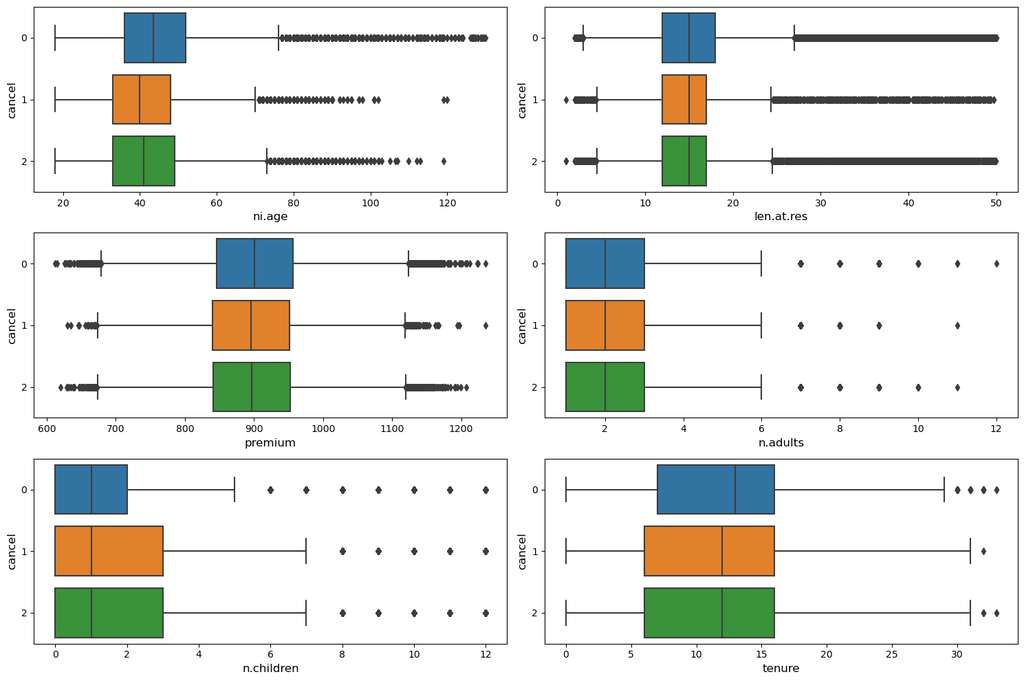

```python
import seaborn as sns
import matplotlib.pyplot as plt

numerical_columns = ['ni.age', 'len.at.res', 'premium', 'n.adults', 'n.children', 'tenure']
fig, axes = plt.subplots(nrows=3, ncols=2, figsize=(15,10))

for i, ax in enumerate(axes.flatten()):
    if i == len(numerical_columns):
        break
    sns.boxplot(x=numerical_columns[i], y='cancel', data=merged_df, ax=ax, orient='h')
    ax.set_xlabel(numerical_columns[i], fontsize=12)
    ax.set_ylabel('cancel', fontsize=12)

plt.tight_layout()
plt.show()
```

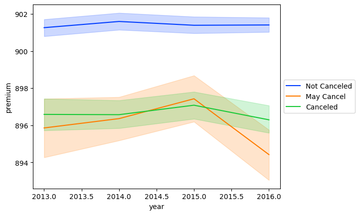

```python
merged_df = pd.merge(X_train, y_train, left_index=True, right_index=True)

# Define the label names and color codes for the legend
legend_labels = {0: 'Not Canceled', 1: 'May Cancel', 2: 'Canceled'}
legend_colors = {0: 'blue', 1: 'orange', 2: 'green'}

# Plot the line plot with Seaborn
ax = sns.lineplot(
    x="year",
    y="premium",
    data=merged_df,
    palette='bright',
    hue='cancel',
    legend='brief'
)

# Get the handles and labels of the current legend
handles, labels = ax.get_legend_handles_labels()

# Create a new legend with custom labels and colors
new_handles = [handles[i] for i in range(len(handles))]
new_labels = [legend_labels[int(label)] for label in labels]
new_colors = [legend_colors[int(label)] for label in labels]
ax.legend(new_handles, new_labels, loc='center left',bbox_to_anchor=(1, 0.5))

# Show the plot
plt.show()
```

### Observations

1. Policies with premium rates above 900 have a "not cancelled" status and this status has remained unchanged from 2013 to 2016.
2. Policies with the premium in range [895-897] have a status of "may cancel but can be convinced". This status has shown an increasing trend with premiums yearly till 2015, after which there is a gradual decrease from 2015 to 2016.
3. The "canceled" status has remained consistent throughout the years and is maintained at a premium rate range of 896-898.

**so, we can say that policies with higher premiums are less likely to be cancelled.**